# Séance 4 : Boucles de programmation

# 1 - Introduction

A présent, ouvrons le jeu de données

```r
jdd <- read.csv("data/Data_exemple.csv", header = TRUE, sep = ",")
head(jdd)
```

```
##   numero         type x_cm y_cm longueur_cm largeur_cm  silex raccord
## 1      1     gravette   10   60         5.0        1.5 type A      NA
## 2      2     gravette   30   50         5.9        1.8 type C      NA
## 3      3     picardie   50   80         3.2        1.2 type B       1
## 4      4      percoir  260  100         4.7        2.1 type B      NA
## 5      5        burin  240  120         6.0        2.4 type B       2
## 6      6 burin diedre  280  150         8.0        3.5 type A      NA
```

# 2 - Créer un plan et un carroyage

Dans un premier temps, nous allons essayer de reproduire un plan de répartition spatiale X, Y, déjà réalisé avec QGIS et Powerpoint. Vous pouvez consulter ce plan dans le dossier `figures` du projet, sous le nom de `plan_exemple.pdf`. L’objectif de cet exercice est de créer un code que vous pourrez ensuite adapter à d’autres données. Cela vous permettra:  
1) de gagner un temps précieux, le code ne prenant que quelques secondes pour générer une figure ;  
2) d’avoir une unité graphique dans votre document en utilisant toujours le même “layout” (agencement de paramètres);  
3) d’organiser les différents éléments de vos figures toujours de la même façon.

Nous allons commencer par créer le carroyage du plan. D’après `plan_exemple.pdf`, la zone d’étude s’étend sur 16 carrés de 1 m de côté, organisés en 4 colonnes et 4 rangées. Vérifions tout d’abord les unités pour les coordonnées des points.

```r
head(jdd)
```

```
##   numero         type x_cm y_cm longueur_cm largeur_cm  silex raccord
## 1      1     gravette   10   60         5.0        1.5 type A      NA
## 2      2     gravette   30   50         5.9        1.8 type C      NA
## 3      3     picardie   50   80         3.2        1.2 type B       1
## 4      4      percoir  260  100         4.7        2.1 type B      NA
## 5      5        burin  240  120         6.0        2.4 type B       2
## 6      6 burin diedre  280  150         8.0        3.5 type A      NA
```

Les coordonnées sont en cm: en x elles se situent entre 10 et 290 cm, et en y entre 50 et 390 cm. Avec un carroyage basé sur des carrés de 1 m de côté, les noeuds auront pour coordonnées (0;0), (0;100), (0;200), etc. Allons-y avec `ggplot2` !

Tout d’abord, définissons les labels des axes :

```r
carres.x <- c("A", "B", "C", "D")
carres.y <- c("1", "2", "3", "4")
```

Créons à présent un objet `ggplot` avec des lignes tous les 100 cm en x et en y.

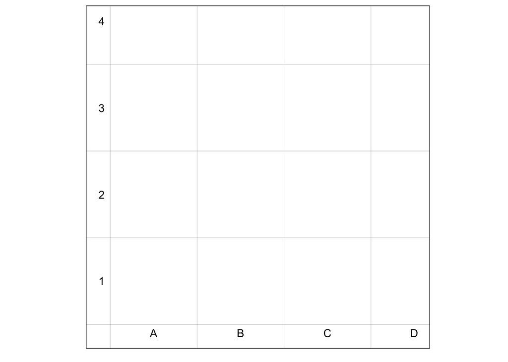

```r
plan <- ggplot2::ggplot() +
    # ces deux premières lignes définissent le thème graphique de la figure
  theme_linedraw() +
  theme(axis.ticks = element_blank(),
        axis.text.x = element_blank(),
        axis.text.y = element_blank(),
        panel.grid.major = element_line(),
        panel.grid.minor = element_blank()) +
  # les deux lignes suivantes permettent de subdiviser les axes tous les 1 m,
  # de 0 à 400 cm, puis en subdivisant les axes tous les 1 m
  scale_x_continuous(breaks = seq(0, 400, by = 100)) +
  scale_y_continuous(breaks = seq(0, 400, by = 100)) +
  coord_fixed(ratio = 1) + # même échelle en x et en y (ratio = 1),
  ylab(element_blank()) +  # enfin, ici on définit les labels des axes
  xlab(element_blank()) +
  annotate (geom = "text",
            x = c(seq(from = 50, to = 400, by = 100)),
            y = -10,
            label = carres.x) +
  annotate (geom = "text",
            x = -10,
            y = c(seq(from = 50, to = 400, by = 100)),
            label = carres.y)
plan
```

Nous pouvons à présent rajouter les points correspondant aux objets ainsi qu’un titre.

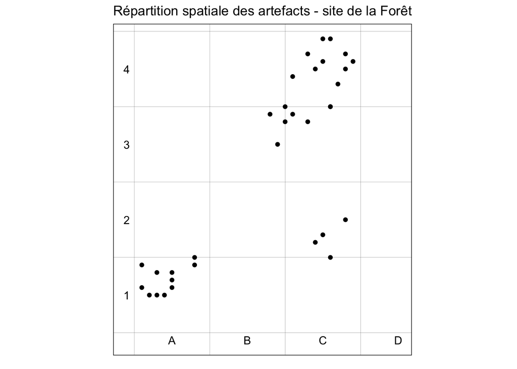

```r
plan +
  geom_point(data = jdd,
             mapping = aes(x = x_cm, y = y_cm)) +
  labs(title = "Répartition spatiale des artefacts - site de la Forêt")
```

La figure s’affiche dans l’onglet `plot`, nous pouvons donc suivre son évolution au fur et à mesure des modifications que l’on souhaite y apporter par la suite.

Ce plan reste toutefois peu informatif sur l’organisation des objets dans le site. Il est possible d’améliorer la figure en faisant varier la forme et la couleur des points en fonction des données qualitatives associées à chaque pièce.

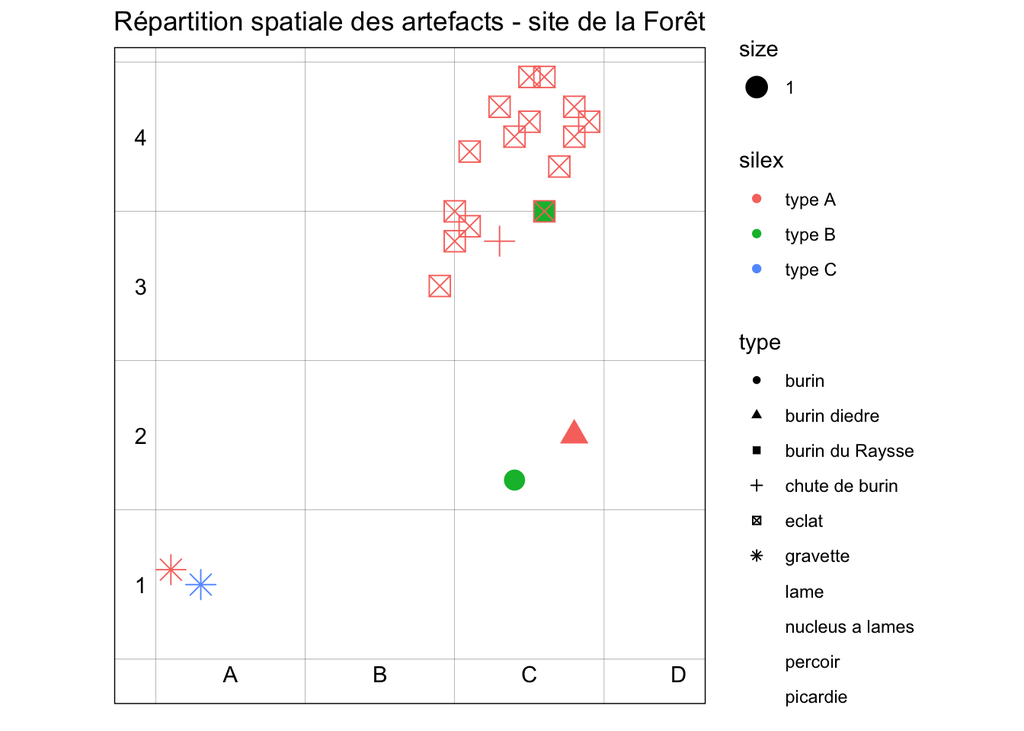

```r
plan +
  geom_point(data = jdd,
             mapping = aes(x = x_cm, y = y_cm,
                           color = silex,
                           shape = type,
                           size = 1)) + # on augmente un peu la taille des points
                                        # pour plus de lisibilité
  labs(title = "Répartition spatiale des artefacts - site de la Forêt")
```

Affichons pour commencer les levels de `type` (après l’avoir converti en factor).

```r
jdd$type_fac <- factor(
  jdd$type,
  # les levels sont dans l'ordre alphabétique ;
  # il est possible de changer leur ordre si on le souhaite
  levels = c("nucleus a eclats laminaires", "burin du Raysse",
             "eclat", "lame", "chute de burin", "burin",
             "burin diedre", "percoir", "picardie", "gravette")
  )
levels(jdd$type_fac)
```

```
##  [1] "nucleus a eclats laminaires" "burin du Raysse"
##  [3] "eclat"                       "lame"
##  [5] "chute de burin"              "burin"
##  [7] "burin diedre"                "percoir"
##  [9] "picardie"                    "gravette"
```

On créé ensuite manuellement la palette de formes avec la fonction `scale_shape_manual()`

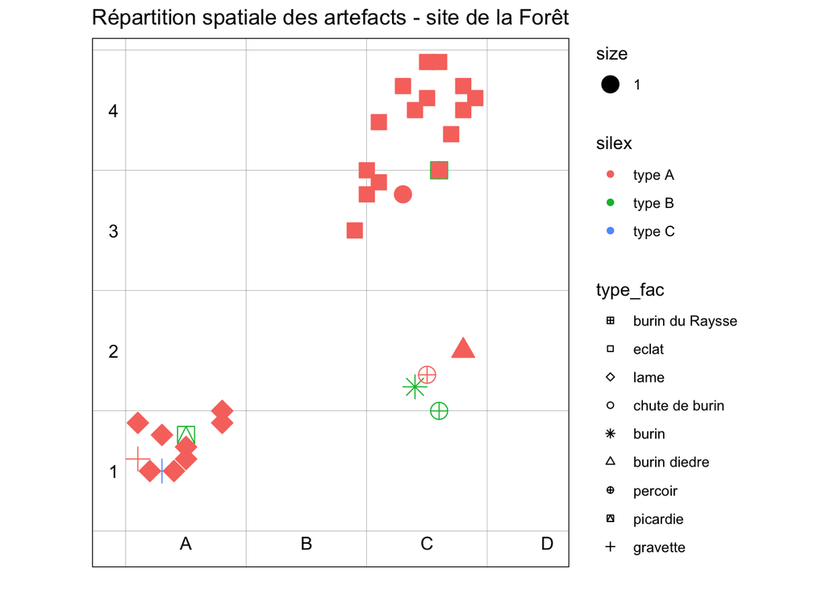

```r
plan +
  geom_point(data = jdd, mapping = aes(x = x_cm, y = y_cm, color = silex,
                                       fill = silex, shape = type_fac, size = 1)) +
  scale_shape_manual(values = c("nucleus a eclats laminaires" = 7,
                                "burin du Raysse" = 12, "eclat" = 22, "lame" = 23,
                                "chute de burin" = 21, "burin" = 8,
                                "burin diedre" = 24, "percoir" = 10,
                                "picardie" = 14, "gravette" = 3)) +
  labs(title = "Répartition spatiale des artefacts - site de la Forêt")
```

On peut aussi faire la même chose pour la palette de couleurs. Utilisons ici les couleurs de la palette `viridis`.

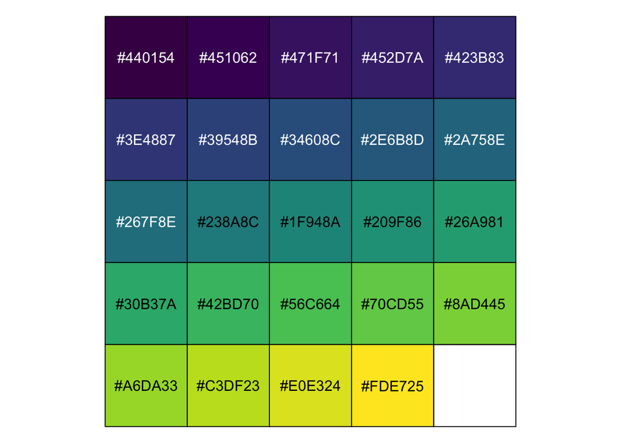

```r
#pour voir la palette on peut utiliser les bibliothèques `pals` et `scales`
#install.packages("pals","scales")
library(pals)
library(scales)
# et la fonction show_col()
show_col(viridis(24))
```

```r
# la fonction viridis() permet d'afficher les codes HEX des couleurs qui
#composent la palette
viridis(n=24)
```

```
##  [1] "#440154" "#451062" "#471F71" "#452D7A" "#423B83" "#3E4887" "#39548B"
##  [8] "#34608C" "#2E6B8D" "#2A758E" "#267F8E" "#238A8C" "#1F948A" "#209F86"
## [15] "#26A981" "#30B37A" "#42BD70" "#56C664" "#70CD55" "#8AD445" "#A6DA33"
## [22] "#C3DF23" "#E0E324" "#FDE725"
```

```r
# Ne pas oublier de convertir en factor !
jdd$silex_fac <- as.factor(jdd$silex)
levels(jdd$silex_fac)
```

```
## [1] "type A" "type B" "type C"
```

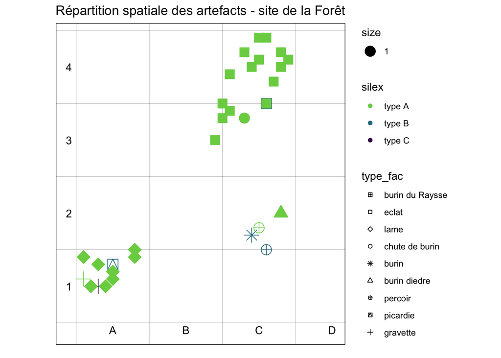

```r
plan +
  geom_point(data = jdd, mapping = aes(x = x_cm, y = y_cm, color = silex,
                                       fill = silex, shape = type_fac, size = 1)) +
  scale_shape_manual(values = c("nucleus a eclats laminaires" = 7,
                                "burin du Raysse" = 12, "eclat" = 22, "lame" = 23,
                                "chute de burin" = 21, "burin" = 8,
                                "burin diedre" = 24, "percoir" = 10,
                                "picardie" = 14, "gravette" = 3)) +
  scale_color_manual(values = c("type A"="#7AD151FF",
                                "type B"="#2A788EFF",
                                "type C"="#440154FF")) +
  scale_fill_manual(values = c("type A"="#7AD151FF",
                               "type B"="#2A788EFF",
                               "type C"="#440154FF")) +
  labs(title = "Répartition spatiale des artefacts - site de la Forêt")
```

La figure est un peu plus facile à comprendre, mais le code pour la produire n’est pas très efficace… remarquez qu’il y a des répétitions (entre les l.178 et 180) et le fait de définir les palettes dans les fonctions complique la lecture.

Pour clarifier tout cela, nous pouvons créer des `objets` qui contiennent nos palettes. Nous n’aurons ensuite qu’à les appeler dans la fonction.

```r
# choisissez vos couleurs et créez votre palette personnalisée
viridis(n=3)
```

```
## [1] "#440154" "#218F8B" "#FDE725"
```

```r
shape <- c("nucleus a eclats laminaires" = 7, "burin du Raysse" = 12,
           "eclat" = 22, "lame" = 23, "chute de burin" = 21, "burin" = 8,
           "burin diedre" = 24, "percoir" = 10, "picardie" = 14,
           "gravette" = 3)
cols <- c("type A"="#7AD151FF", "type B"="#2A788EFF", "type C"="#440154FF")
```

Pour alléger encore, on place les palettes et le titre dans l’objet `plan.modif`.

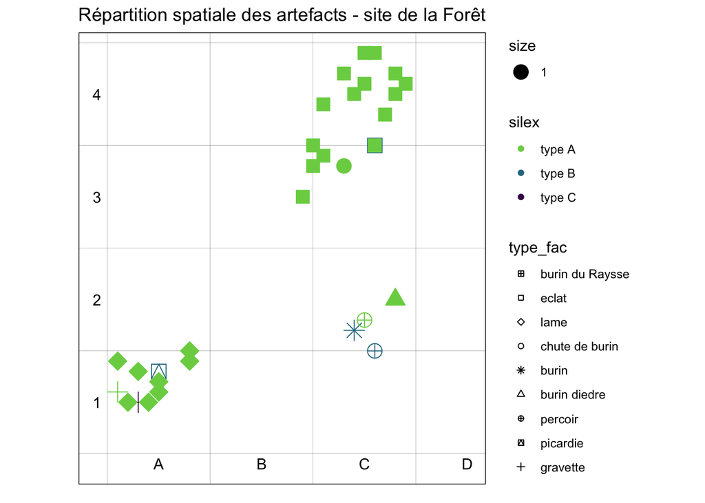

```r
plan.modif <- plan +
  scale_shape_manual(values = shape) +
  scale_color_manual(values = cols) +
  scale_fill_manual(values = cols) +
  labs(title = "Répartition spatiale des artefacts - site de la Forêt")

plan.modif +
geom_point(data = jdd,
           mapping = aes(x = x_cm, y = y_cm,
                         color = silex,
                         fill = silex,
                         shape = type_fac,
                         size = 1)) # Même résultat !
```

Modifions à présent la légende pour la rendre plus lisible

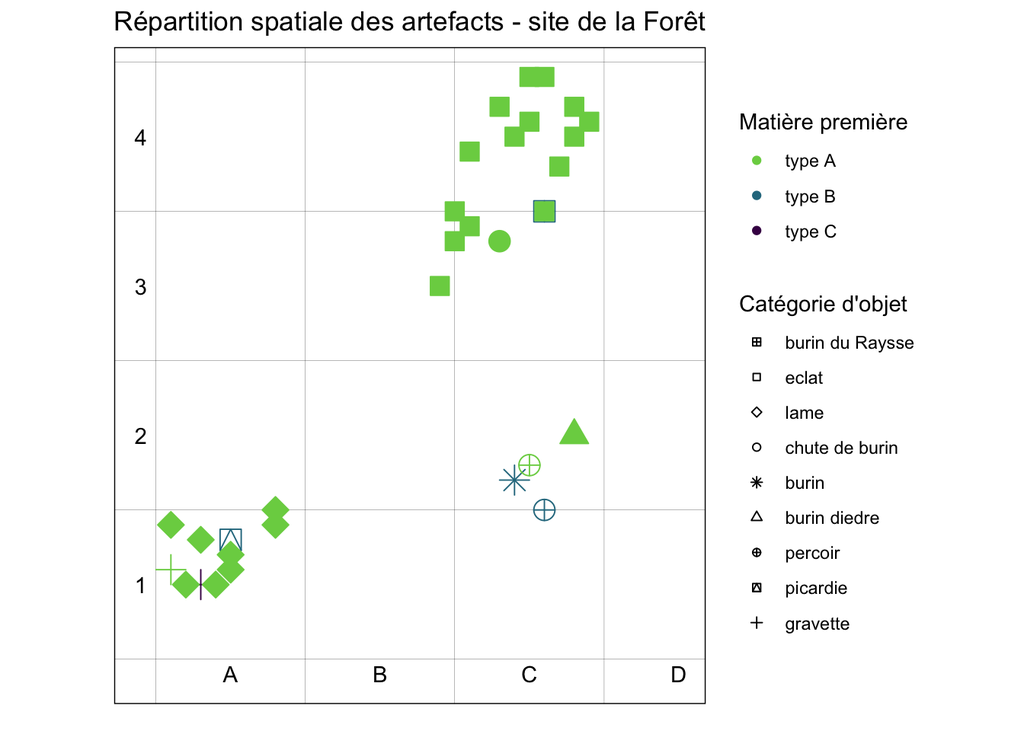

```r
plan.modif +
  geom_point(data = jdd, mapping = aes(x = x_cm, y = y_cm, color = silex,
                                       fill = silex, shape = type_fac, size = 1)) +
    # ici on va changer le titre des légendes
  labs(color = "Matière première", shape = "Catégorie d'objet") +
    # et là, nous pouvons supprimer les légendes que nous ne souhaitons pas voir apparaître dans la figure finale.
  guides(fill = "none", size = "none")
```

# 3 - Sélectionner des données à afficher

Dans cette nouvelle partie, nous allons apprendre comment sélectionner une partie des données, dans l’idée d’un requêtage permettant ensuite d’afficher une portion seulement des données initiales. Cette opération est très pratique par exemple pour réaliser des projections localisées sans avoir à modifier le tableau excel de base, ce qui est plus transparent et permet de limiter les erreurs possibles.

Découvrons comment mettre en oeuvre cette opération. Dans les quelques lignes suivantes, nous allons sélectionner les pièces qui ont fait l’objet d’un raccord ou d’un remontage afin de représenter la relation entre les pièces sur le plan.

Pour cela, nous allons créer un nouveau dataframe dans lequel nous allons “ranger” uniquement les lignes qui contiennent des données pour la variable `raccord`

```r
rac <- jdd[complete.cases(jdd$raccord), ]
# addddddddd is.na
```

Les **crochets** permettent de dire à R que l’on va sélectionner des lignes (premier argument) ou des colonnes (deuxième argument) dans le data frame `jdd`. La fonction `complete.cases()` permet ensuite de repérer les cases qui ne sont pas vides. Cette ligne de code nous permet donc de sélectionner dans `jdd` les lignes pour lesquelles la valeur de raccord est renseignée.

Observons ce que cela donne :

```r
head(jdd)
```

```
##   numero         type x_cm y_cm longueur_cm largeur_cm  silex raccord
## 1      1     gravette   10   60         5.0        1.5 type A      NA
## 2      2     gravette   30   50         5.9        1.8 type C      NA
## 3      3     picardie   50   80         3.2        1.2 type B       1
## 4      4      percoir  260  100         4.7        2.1 type B      NA
## 5      5        burin  240  120         6.0        2.4 type B       2
## 6      6 burin diedre  280  150         8.0        3.5 type A      NA
##       type_fac silex_fac
## 1     gravette    type A
## 2     gravette    type C
## 3     picardie    type B
## 4      percoir    type B
## 5        burin    type B
## 6 burin diedre    type A
```

```r
head(rac)
```

```
##   numero            type x_cm y_cm longueur_cm largeur_cm  silex raccord
## 3      3        picardie   50   80         3.2        1.2 type B       1
## 5      5           burin  240  120         6.0        2.4 type B       2
## 8      8 burin du Raysse  260  300         5.3        3.8 type B       1
## 9      9  chute de burin  230  280         2.0        0.5 type A       2
##          type_fac silex_fac
## 3        picardie    type B
## 5           burin    type B
## 8 burin du Raysse    type B
## 9  chute de burin    type A
```

Dans la data frame `jdd`, notez bien la présence de cases vides (`NA`) dans la colonne `raccord`. En revanche dans `rac`, seules les lignes pour lesquelles la valeur de `raccord` est renseignée (1 ou 2 en l’occurrence) sont présentes. Il n’y a donc que 4 pièces concernées.

Nous pouvons maintenant rajouter un lien entre les pièces en utilisant cette nouvelle data frame.

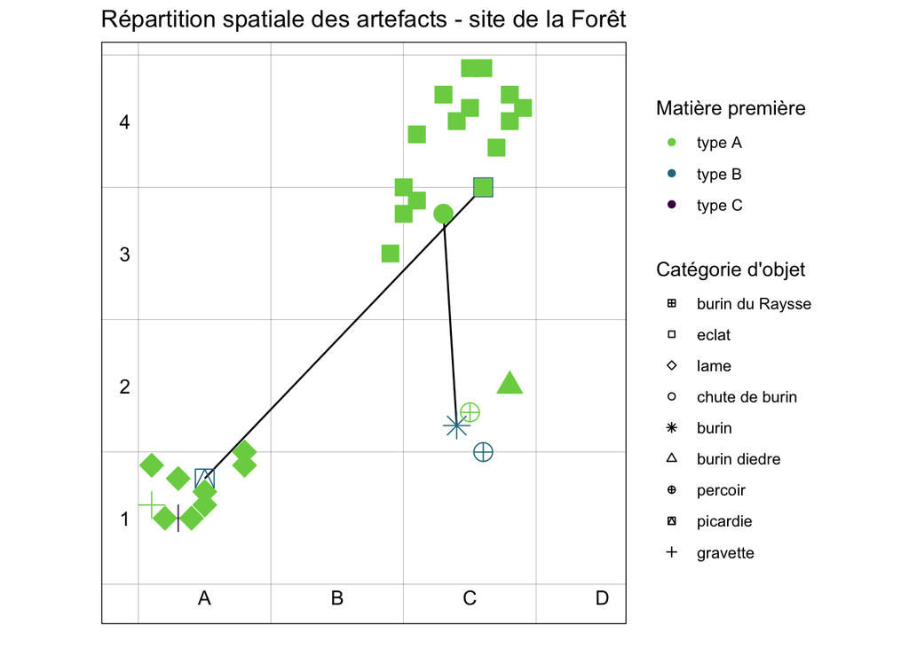

```r
plan.modif +
  geom_line(data = rac, mapping = aes(x = x_cm, y = y_cm, group = raccord),
            linewidth = 0.5) + # l'argument 'group' permet de relier les pièces
                               # par groupe de mêmes valeurs
  geom_point(data = jdd, mapping = aes(x = x_cm, y = y_cm, color = silex,
                                       fill = silex, shape = type_fac, size = 1)) +
    # légende
  labs(color = "Matière première", shape = "Catégorie d'objet") +
  guides(fill = "none", size = "none")
```

Une autre façon de faire des sélections au sein d’une data frame est d’utiliser la fonction `subset()`. Cette fonction permet d’introduire des conditions plus complexes pour la sélection de lignes ou de colonnes, en utilisant des connecteurs logiques.

Par exemple, essayons de sélectionner les pièces situées entre 200 et 400 cm en x, et entre 300 et 500 cm en y.

```r
jdd.zoom <- subset(jdd, x_cm >= 200 & x_cm <= 400
                      & y_cm >= 300 & y_cm <= 500)
```

Pour créer `jdd zoom`, nous demandons R de renvoyer les lignes du data frame dont le x est supérieur ou égal (>=) à 200 ET (&) inférieur ou égal (<=) à 400 ET (&) dont le xy est supérieur ou égal (>=) à 300 ET (&) inférieur ou égal (<=) à 500.

Voyons le résultat sur le plan

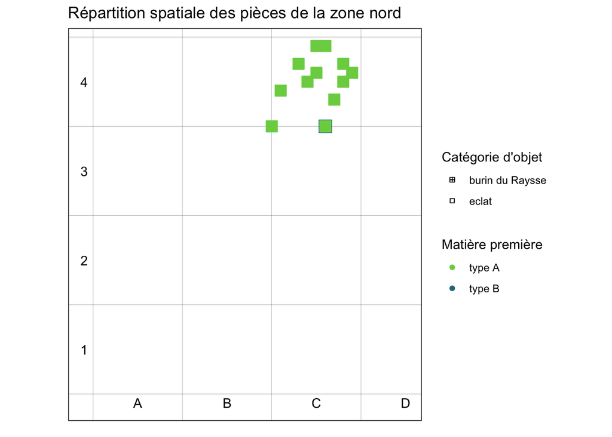

```r
plan.modif +
  geom_point(data = jdd.zoom, mapping = aes(x = x_cm, y = y_cm, color = silex,
                                            fill = silex, shape = type_fac, size = 1)) +
    # titre et légende
  labs(title = "Répartition spatiale des pièces de la zone nord",
       color = "Matière première", shape = "Catégorie d'objet") +
  guides(fill = "none", size = "none")
```

Les connecteurs logiques permettent de personnaliser vos sélections très facilement. Voici les différentes possibilités :

**<** : “strictement inférieur à”  
**<=** : “inférieur ou égal à”  
**>** : “strictement supérieur à”  
**>=** : “supérieur ou égal à”  
**&** : “et”  
**|** : “ou”  
**==** : “strictement égal à”  
**!=** : “non égal à”  
**!x** : “différent de x”  
**isTRUE(x)** : teste si x est TRUE

## 3.1 - Quelques exemples !

On sélectionne les pièces qui ne sont pas en silex de type A

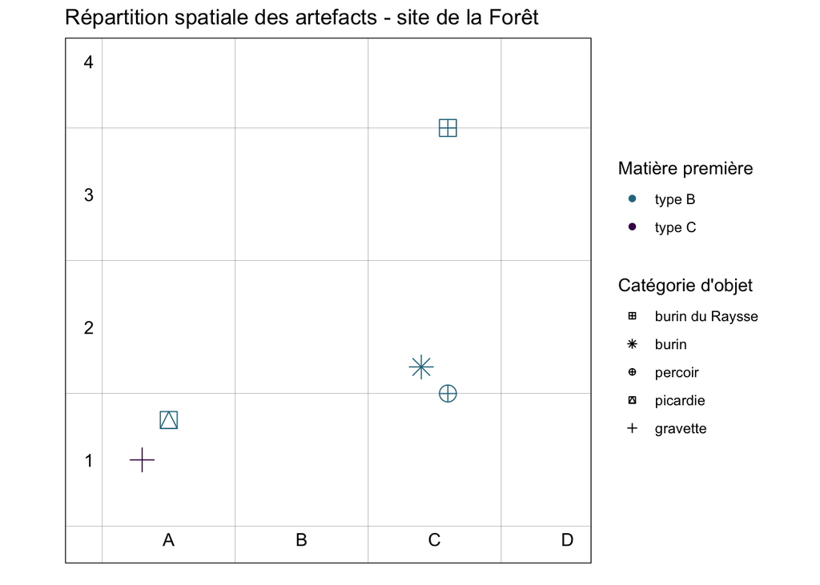

```r
jdd.silexBC <- subset(jdd, silex != "type A",)

plan.modif +
  geom_point(data = jdd.silexBC, mapping = aes(x = x_cm, y = y_cm, color = silex,
                                               fill = silex, shape = type_fac, size = 1)) +
  # titre et légende
  labs(titre = "Répartition spatiale des objets en silex autres que de type A",
       color = "Matière première", shape = "Catégorie d'objet") +
  guides(fill = "none", size = "none")
```

On sélectionne les lames et éclats non retouchés et nucléus à éclats laminaires

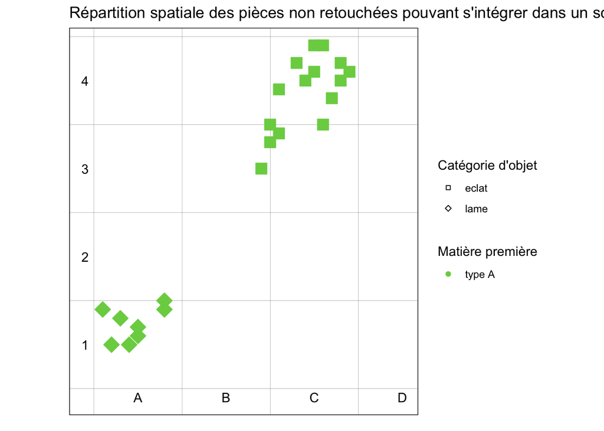

```r
jdd.lamn <- subset(jdd, type == "eclat" | type == "lame" | type == "nucleus a eclats laminaires",)

plan.modif +
  geom_point(data = jdd.lamn, mapping = aes(x = x_cm, y = y_cm, color = silex,
                                             fill = silex, shape = type_fac, size = 1)) +
  # titre et légende
  labs(title = "Répartition spatiale des pièces non retouchées pouvant s'intégrer dans un schéma laminaire",
       color = "Matière première", shape = "Catégorie d'objet") +
  guides(fill = "none", size = "none")
```

# 4 - Automatiser un code : le principe des boucles

Nous entrons à présent dans la dernière partie de ce TP, et peut-être la plus utile… l’automatisation d’un code ! Ce processus signifie que l’on va demander au code de réaliser plusieurs fois la même opération mais sur des données différentes. Pour cela, il existe deux fonctions permettant de répéter un bout de code tant qu’une certaine condition ne sera pas atteinte : `for()` et `while()`. Nous allons les découvrir ensemble sur des exemples très simples, puis nous verrons un exemple avec le jeux de données archéologique.

## 4.1 - Boucles `for()`

Une boucle `for()` permet de **répéter un bout de code tant qu’une certaine valeur (par convention, on l’appelle `i`) se situe dans un certain intervalle**.

Créons un objet `x` contenant la valeur “0”.

```r
x <- 0
```

Nous allons y ajouter des valeurs à l’aide d’une boucle :

```r
i <- 1 # tout d'abord, on initialise la valeur i

for(i in 1:5) # conditions de la boucle : tant que i se trouve dans ("in") l'intervalle 1 à 5 (défini par ":"), répéter le code suivant.
  { # on ouvre la boucle
  x <- c(x, i) # on place la valeur i dans l'objet x.

  i <- i + 1 # on incrémente i de 1
}
```

Affichons le résultat :

```r
x
```

```
## [1] 0 1 2 3 4 5
```

Nous avons bien réussi à créer une suite de nombres ! Cet exemple est certes trivial, mais nous verrons un peu plus tard comment l’appliquer sur des données et avec des opérations plus complexes.

Petite note à ce stade : la dernière ligne de notre boucle, `i <- i + 1`, est facultative dans R. La fonction `for()` permet en effet d’incrémenter automatique la valeur `i` de 1 à chaque fin de boucle.  
Voici la preuve :

```r
y <- 0

for(i in 1:5) {
  y <- c(y, i)
}

y # même résultat !
```

```
## [1] 0 1 2 3 4 5
```

## 4.2 - Boucles `while()`

L’autre type de boucle est moins fréquemment utilisée, mais peut toujours être utile. Il s’agit d’une boucle `while()` : c’est à dire que l’on va **répéter le code tant qu’une certaine condition est remplie**. Une fois qu’elle ne l’est plus, la boucle est terminée.

Essayons avec un autre exemple simple : nous allons créer un code qui va afficher une valeur tant que celle-ci est inférieure à 5.

```r
i <- 1 # initialisation de la valeur

while(i <= 5) # cette ligne de code se lit : tant que i est inférieur ou égal à 5, répéter le code suivant
  { # début de la boucle
  print(i) # afficher "i" dans la console

  i <- i + 1 # incrémenter i de 1
             # ATTENTION: l'incrémentation ne se fait pas automatiquement avec while() !!!
} # fin de la boucle
```

```
## [1] 1
## [1] 2
## [1] 3
## [1] 4
## [1] 5
```

Dans la mesure du possible, nous vous conseillons d’utiliser plutôt les boucles `for()`, car ce sont elles qui sont plus utilisée dans la communauté. `while()` est également très bien et vous pouvez arriver au même résultat qu’avec une boucle `for()`, mais l’utilisation de `for()` fait vraiment partie de la “culture R” en tant que culture de programmation !

## 4.3 - Exemple sur le jeu de données du site de la Forêt

Mettons en pratique ce concept sur le jeu de données du site de la Forêt. Nous allons créer plusieurs plans de répartition en fonction de la dimensions des pièces. Tout d’abord, rafraîchissons nous la mémoire sur les statistiques basiques du jeu de données.

```r
summary(jdd)
```

```
##      numero       type                x_cm            y_cm        longueur_cm
##  Min.   : 1   Length:33          Min.   : 10.0   Min.   : 50.0   Min.   : 1.4
##  1st Qu.: 9   Class :character   1st Qu.: 50.0   1st Qu.: 90.0   1st Qu.: 4.5
##  Median :17   Mode  :character   Median :210.0   Median :280.0   Median : 5.9
##  Mean   :17                      Mean   :174.8   Mean   :217.6   Mean   : 5.8
##  3rd Qu.:25                      3rd Qu.:260.0   3rd Qu.:340.0   3rd Qu.: 7.4
##  Max.   :33                      Max.   :290.0   Max.   :390.0   Max.   :10.2
##
##    largeur_cm       silex              raccord               type_fac
##  Min.   :0.500   Length:33          Min.   :1.0   eclat          :15
##  1st Qu.:1.900   Class :character   1st Qu.:1.0   lame           : 8
##  Median :2.800   Mode  :character   Median :1.5   percoir        : 2
##  Mean   :2.976                      Mean   :1.5   gravette       : 2
##  3rd Qu.:3.700                      3rd Qu.:2.0   burin du Raysse: 1
##  Max.   :7.100                      Max.   :2.0   (Other)        : 4
##                                     NA's   :29    NA's           : 1
##   silex_fac
##  type A:28
##  type B: 4
##  type C: 1
##
##
##
##
```

La longueur des pièces se situe entre 1.4 et 10.2 cm. Je vous propose donc de créer un plan pour des intervalles de longueurs tous les 2 cm. Nous allons donc devoir combiner les commandes de **subsetting** et le **loop `for()`**.

```r
i <- 1
pace <- 2 # ici il s'agit de la valeur d'intervalle ; dans ce cas concret, il est nécessaire de la spécifier étant donné qu'elle est différente de la valeur par défaut (1)
```

Je crée également un dossier afin de pouvoir sauvegarder les plots au fur et à mesure.

```r
dir.create("figures/plans_fct_longueur")
```

Démarrons la boucle !

```r
for(i in 1:11) { # Cette boucle va s'exécuter tant que i sera compris entre 1 et 11

  ## Je commence par créer les bornes de l'intervalle i
  borne.min <- i # le minimum est i
  borne.max <- i + pace # et le maximum est i + pace, soit i + 2

  ## Ensuite, je subset le jeux de données pour ne sélectionner que les pièces dont la longueur est comprise entre la borne min et la borne max de mon intervalle.
  repart <- subset(jdd, longueur_cm >= borne.min & longueur_cm <= borne.max)

  ## maintenant, on crée le plan de répartition avec les données sélectionnées
  plan.modif +
    geom_point(data = repart, mapping = aes(x = x_cm, y = y_cm, color = silex,
                                              fill = silex, shape = type_fac, size = 1)) +
    # titre et légende
    labs(title = paste0("Répartition spatiale des pièces dont L est comprise entre ", borne.min,  " et ", borne.max, "cm"),
         ### NB : ici, on va utiliser la fonction paste0() pour adapter le titre de la figure à chaque intervalle.
         ### Cette fonction est extrêmement utile, retenez la ! Elle permet de coller côte à côte des objets en les transformant en texte.
         color = "Matière première",
         shape = "Catégorie d'objet") +
    guides(fill = "none", size = "none")

  ## Enfin, on sauvegarde la figure dans le dossier "plans_fct_longueur" en adaptant son titre avec paste() - cette fonction est un peu différente de paste0() en cela qu'elle recquiert que l'on précise un séparateur à ajouter entre les blocs de texte. Ici ce sera "_" (argument "sep").
  ggsave(paste("figures/plans_fct_longueur/repart_pieces_entre ", borne.min, "et", borne.max, ".png", sep = "_"),
         width = 6, height = 4)
}
```

FELICITATIONS ! Vous avez fait votre première boucle sur R !!